# An Unsuperised Analysis into Kenya Counties: Clustering and Dimension Reduction

Giovanny Martinez Rodriguez, Na Nguyen, Rishika Kundu

# Data import and cleaning

```r
# Loading necessary libraries
library(corrplot)
library(dplyr)
library(tidyverse)
library(factoextra)
library(tidymodels)
library(reshape2)
library(sp)
library(sf)
library(plotly)
library(cowplot)

# Read in original data
kenya <- read.csv("kenya_census.csv")

# Function to divide designated columns in a dataset by a total variable
per_capita <- function(dataset, var, cols) {
  cols <- dataset %>%
    select(cols) %>%
    colnames()

  dataset<-dataset %>%
      mutate(across(.cols = cols, ~ . / {{var}}))
  return(dataset)
}

# Applying function to create census data
kenya_census <- per_capita(kenya, Population, 15:17)
kenya_census <- per_capita(kenya_census, NumberOfHouseholds, 5:14)

# Read in Kenya county shape files
kenya_sf <- read_sf("kenyan-counties") %>%
  mutate(COUNTY = str_to_lower(COUNTY))

# Seeing unmatched pairs from 2 datasets
kenya_census %>%
  anti_join(kenya_sf, by = c('County' = 'COUNTY'))
```

```
##            County Population NumberOfHouseholds AverageHouseholdSize   Farming
## 1    taita/taveta     335747              96429                  3.5 0.5902789
## 2   tharaka-nithi     391303             109860                  3.6 0.7806936
## 3 elgeyo/marakwet     453403              99861                  4.5 0.7498523
##           Tea     Coffee    Avocado     Citrus     Mango    Coconut  Macadamia
## 1 0.000000000 0.00000000 0.08257889 0.03405614 0.0743656 0.02596729 0.03785168
## 2 0.065783725 0.14374659 0.11988895 0.01483707 0.1283634 0.00000000 0.08447115
## 3 0.007520453 0.01391935 0.05231271 0.01634272 0.0643895 0.00000000 0.00518721
##    Cashew.Nut Khat..Miraa.      Male    Female     Intersex  Total
## 1 0.005631086   0.00000000 0.5162727 0.4983723 2.084903e-05 340671
## 2 0.000000000   0.07649736 0.4951764 0.5095949 1.788895e-05 393177
## 3 0.000000000   0.00000000 0.5013575 0.5009914 2.646652e-05 454480
```

```r
# Wrangling Kenya data and creating Kenya Map data by joining sf and census data
kenya_map <- kenya_sf %>%
  mutate(COUNTY = case_when(
    COUNTY == "taita taveta" ~"taita/taveta",
    COUNTY == "tharaka" ~ "tharaka-nithi"  ,
    COUNTY == "keiyo-marakwet" ~"elgeyo/marakwet" ,
    TRUE ~ COUNTY
  )) %>%
  inner_join(kenya_census, by = c('COUNTY' = 'County')) %>%
  select(-Total, -Population, -NumberOfHouseholds)


kenya_census <- kenya_census %>%
  column_to_rownames("County")

kenya_census <- kenya_census %>%
  select(-Total, -Population, -NumberOfHouseholds)
```

# Clustering analysis

## Write-up

### K-means Clustering

When performing the K-means model, we first use a silhouette method that chooses K to maximize the distance between clusters and minimizes distance within clusters. This resulted in K equals to 9 clusters. This is a very large value for K given that our dataset only has 41 counties. This might be due to the small size of our dataset and data points being too well-separated. 9 clusters, consequently, cannot give us the best grouping and interpretability for our dataset. Rather, the algorithm might be creating clusters that capture noise or irrelevant patterns in the data, leading to inflated silhouette scores. Hence, given the size and context of the dataset , which results in difficulties when choosing K, and an unreasonable value of K using the silhouette method, we’ll continue our analysis using a hierarchical clustering method, which we believe is a better approach.

### Hierarchical Clustering

According to the hierarchical clustering model, roughly 4 natural clusters can be seen in the dendogram. 4 seems like an appropriate number of clusters given the fact that the dataset contains only 41 observations which could lead to clusters with roughly 10 counties each on average. Furthermore, maximum distance within clusters is 7.5, which is where cluster 2 (colored in purple) fuses, whereas other 3 clusters fuse at roughly a height of 6. Given the context of the data with maximum distance between any two pairs of counties in the dendogram being 10, the height of 6 allows to reduce amount of variability by 40 percent within each cluster. Thus, we examine 4 clusters in the dataset.

Hierarchical clustering further allows for open and different interpretation of the dendogram while visualizing structures within the clusters. Cluster 3 (in green) includes sub-groups whereas cluster 2 (in purple) is fused at the highest point which shows greater variability within the cluster. We further used complete linkage since we want all our clusters to have similar characteristics.

The first cluster of counties is not a farming cluster and does not specialize in growing any crops. However, this is the cluster with the highest average household size and contains the second highest number of counties (11). Therefore, it is probably a cluster of urban counties. Counties such as Mombasa, Garissa, Wajir, etc that are included in cluster 1 are all urban cities or towns.

- Cluster 2,3, and 4 are farming oriented counties that each specialize in a variety of crops.
- Cluster 2 is the smallest cluster with 4 counties and specializes in cashew, coconut and mango production.
- Cluster 3 is the largest cluster with 20 counties and primarily produce avocado along with tea and mango.
- Cluster 4 produces avocado, coffee, khatmiraa, macadamia, and tea.
- The male and female gender distribution is roughly the same across all clusters. However, cluster 1 has the largest proportion of intersex population with cluster 2 and 3 having lowest proportion.

Considering the size of our dataset, we would move forward with our Hierarchical Clustering Model with 4 clusters as the approach to identify similarities between each county in Kenya. Furthermore, as seen in the hierarchical clustering map, clusters of counties identified are also geographically close to each other. This approach gives meaningful clusters in terms of agricultural expertise and geographical locations (urban vs rural).

## Code and plots

### K-means

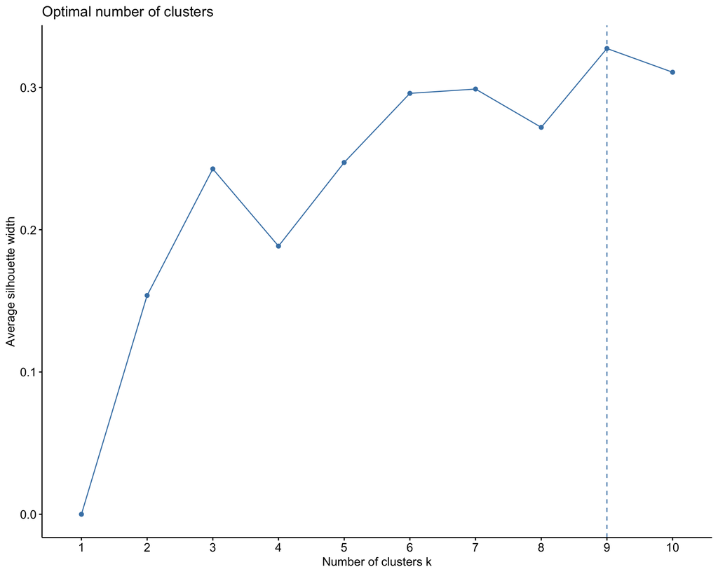

```r
# Choosing K
fviz_nbclust(scale(kenya_census), kmeans, method='silhouette')
```

```r
# K-means clustering
set.seed(253)
kmeans_model <- kmeans(kenya_census, centers = 9, nstart = 50)

# Get the "the total within- cluster sum of squares"
# This is the total squared distance of each case from its assigned centroid
tot.within <- kmeans_model$tot.withinss

# Assign each sample case to a cluster
# We typically want to store this in a new dataset so that the cluster assignments aren't
# accidentally used as features in a later analysis!
cluster_kenya <- kenya_census %>%
  mutate(kmeans_cluster_k = kmeans_model$cluster)
```

### Hierarchical Clustering

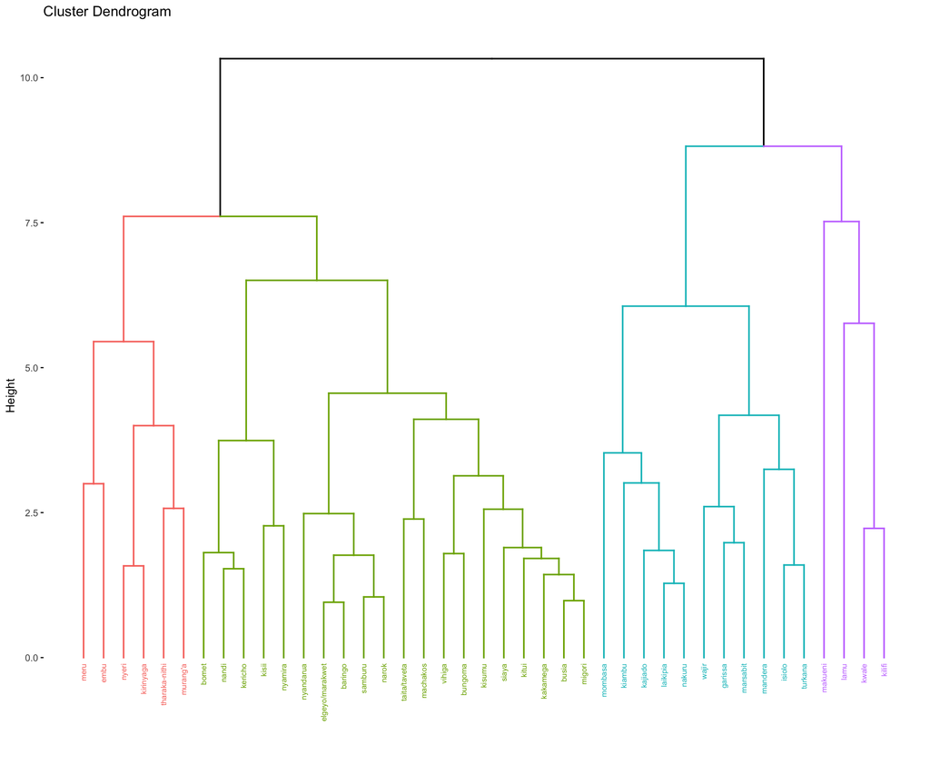

```r
# Creating Hierarchical Clustering Model
hier_model_1 <- hclust(dist(scale(kenya_census)), method = "complete")

# Creating Hierarchical Clustering Model Dendogram
fviz_dend(hier_model_1, k = 4, cex = .5)
```

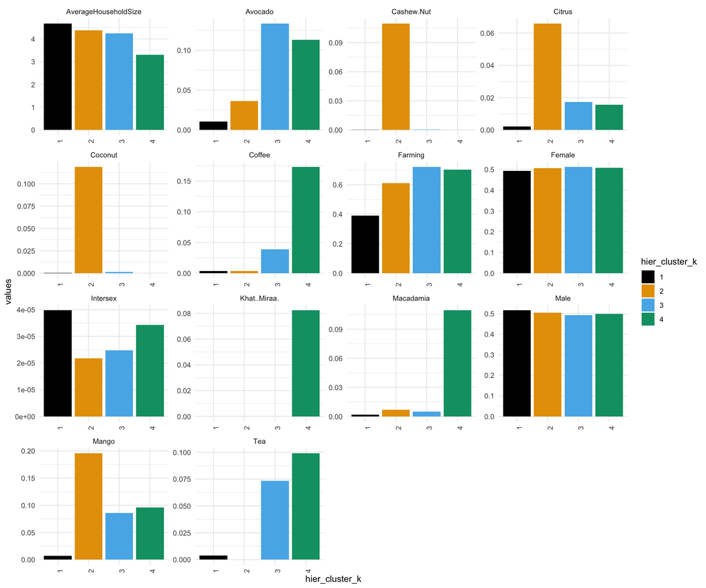

```r
# Creating a column for the clusters and their mean respective to every feature in the dataset.
kenya_census_1 <- kenya_census %>%
  mutate(hier_cluster_k = as.factor(cutree(hier_model_1, k = 4))) %>%
  group_by(hier_cluster_k) %>%
  summarize_all(mean)

# Bar plot showing the characteristics of each cluster.
kenya_census_1 %>%
  pivot_longer(cols = 2:15, names_to = "variables", values_to = "values") %>%
  ggplot(aes(x=hier_cluster_k, y = values, fill = hier_cluster_k )) +
  geom_bar(stat="identity") +
  facet_wrap(~variables,scales='free') +
  theme_minimal()+
  theme(axis.text.x = element_text(angle = 90))
```

```r
 kenya_census %>%
  mutate(hier_cluster_k = as.factor(cutree(hier_model_1, k = 4))) %>%
   count(hier_cluster_k)
```

```
##   hier_cluster_k  n
## 1              1 11
## 2              2  4
## 3              3 20
## 4              4  6
```

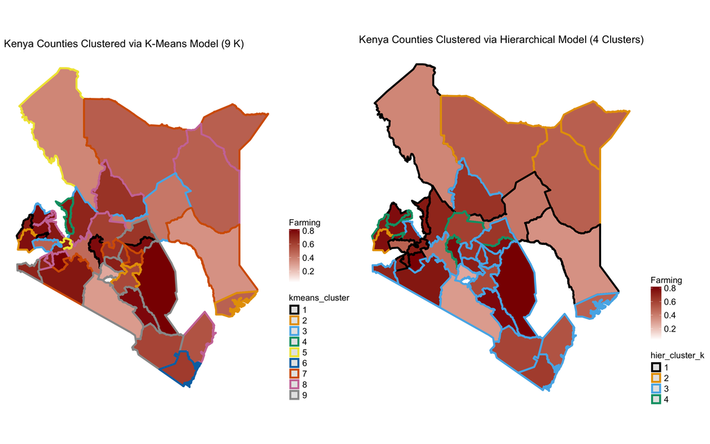

```r
# Kenya County Clusters Map by Clustering Models

# Combine the plots using cowplot
combined_plot <- plot_grid(
  kenya_map %>%
    mutate(kmeans_cluster = as.factor(kmeans_model$cluster)) %>%
    ggplot() +
    geom_sf(aes(color = kmeans_cluster, fill = Farming), linewidth = 1.5) +
    ggthemes::theme_map() +
    labs(title = "Kenya Counties Clustered via K-Means Model (9 K)") +
    scale_fill_gradient(low = "white", high = "darkred") +
    theme(legend.position = "right",
          plot.title = element_text(size = 17),
          legend.title =  element_text(size = 14),
          legend.text =  element_text(size = 14)),

  kenya_map %>%
    mutate(hier_cluster_k = as.factor(cutree(hier_model_1, k = 4))) %>%
    ggplot() +
    geom_sf(aes(color = hier_cluster_k, fill = Farming), linewidth = 1.5) +
    ggthemes::theme_map() +
    labs(title = "Kenya Counties Clustered via Hierarchical Model (4 Clusters)") +
    scale_fill_gradient(low = "white", high = "darkred") +
    theme(legend.position = "right",
          plot.title = element_text(size = 17),
          legend.title =  element_text(size = 14),
          legend.text =  element_text(size = 14)),

  ncol = 2  # Set the number of columns in the grid
)

# Print the combined plot
print(combined_plot)
```

# Dimension reduction analysis

## Write-up

### The features of the first 2 PCs

- **Principle component 1**: PC1 is driven by `Farming` (negative contribution) and crop features such as `Avocado` and `Coffee` (negative contribution), `Male`(positive contribution), and `Female` (negative contribution). When observing our score plot, there is a cluster of cities that have a large positive PC1 value between 2.5 and 5. For example, mandera, mombasa, turkana, marsabit, wajir, isiolo, and garissa. This means that these observations either have a large negative `Farming` PC value, a large negative crop feature PC value (e.g., `Avocado`, `Coffee`, and `Tea`), a large positive `Male` PC value, and/or a large negative `Female` PC value.

- **Principle component 2**: PC2 is driven by fruit/nut-bearing crop features such as `Citrus`, `Mango`, `Coconut`, and `Cashew Nut` (negative contribution). When observing our score plot, there is a cluster of cities that have a large negative PC2 value between -3 and -5. For example makueni, kilifi, kwale, and lamu. This means that these observations either have a large positive `Citrus`, `Mango`, `Coconut`, and/or `Cashew Nut` PC value.

### Final PCs and information retained

From our findings through investigating the first 2 PCs and our Hierarchical Clustering Model, we observed that our data exhibits high variability, high separatedness, and rather complex patterns. This indicate that we might need to retain more variability to capture the nuances in the data. Therefore, we would suggest moving forward with 4 PCs, with which we will retain 75% of our original information.

## Code and plots

```r
# Creating Principle Components

pca_kenya <- kenya_census %>%
  prcomp(scale = TRUE, center = TRUE)
```

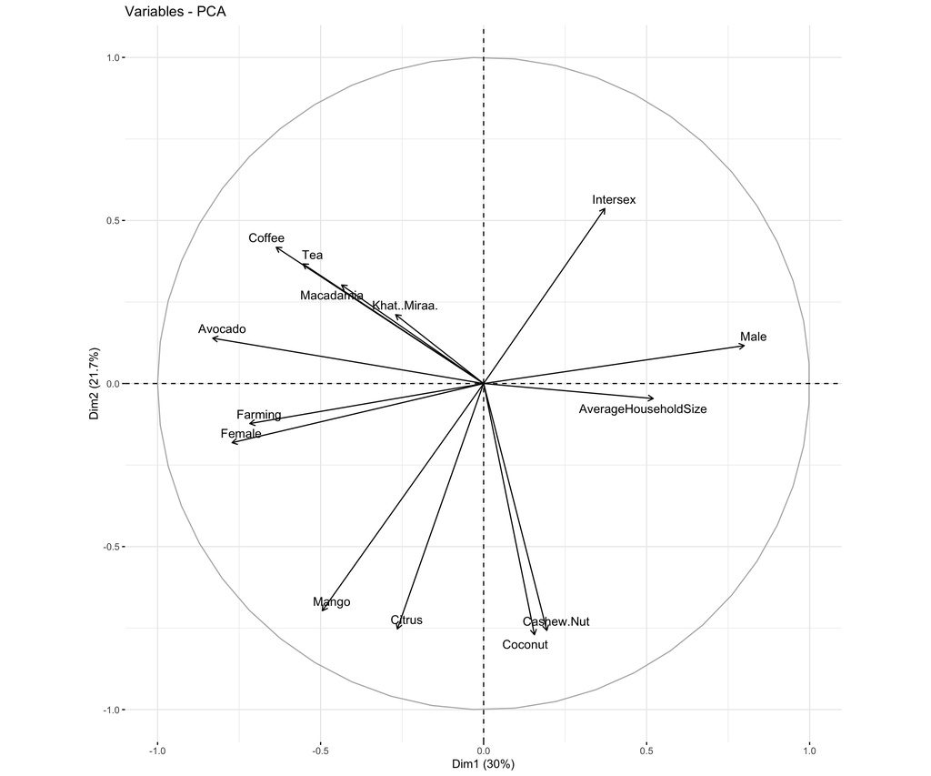

```r
# Loading plot of the first 2 PCs
fviz_pca_var(pca_kenya, repel = TRUE)
```

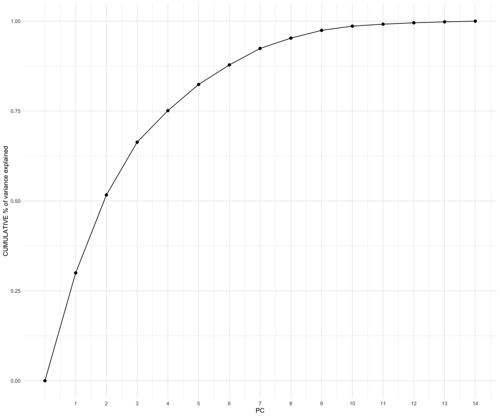

```r
# Cumulative % of variance explained by PC
pca_kenya %>%
  tidy(matrix = "eigenvalues") %>%
  rbind(0) %>%
  ggplot(aes(y = cumulative, x = PC)) +
    geom_point(size = 2) +
    geom_line() +
    scale_x_continuous(breaks = seq(1,14, by =1))+
    labs(y = "CUMULATIVE % of variance explained")+
  theme_minimal()
```

```r
# Exploring weight of each feature in each PC
pca_kenya %>%
  pluck("rotation") %>%
  head()
```

```
##                             PC1         PC2         PC3        PC4        PC5
## AverageHouseholdSize  0.2538774 -0.02644171  0.26609788 0.30235293  0.4570702
## Farming              -0.3499650 -0.07045490  0.12268312 0.10230124  0.4350039
## Tea                  -0.2704005  0.21063057  0.03379302 0.61021107 -0.1093558
## Coffee               -0.3104625  0.23987926 -0.30901154 0.26274437 -0.1026911
## Avocado              -0.4054943  0.07982962  0.18221897 0.28963408  0.1210159
## Citrus               -0.1291271 -0.43203792 -0.17780463 0.01009741  0.2459861
##                              PC6        PC7         PC8         PC9        PC10
## AverageHouseholdSize -0.31623122  0.4233066 -0.00243406 -0.42754985 -0.21828815
## Farming              -0.11080150  0.2853562 -0.28893851  0.67218688  0.07598708
## Tea                  -0.03598602 -0.2100203  0.26065772  0.07897346 -0.28200367
## Coffee                0.12994751  0.1252336 -0.33995193 -0.31026947 -0.04706300
## Avocado               0.11874123 -0.1164257  0.25070910 -0.18568905  0.44040929
## Citrus                0.43699898 -0.1097298  0.23710141  0.07688579 -0.57700517
##                             PC11        PC12        PC13        PC14
## AverageHouseholdSize  0.06747999  0.12455430  0.16916714 -0.07333867
## Farming               0.03147673 -0.07455443 -0.07928131  0.10090064
## Tea                  -0.23001412  0.39508395 -0.22730133  0.19310000
## Coffee                0.58711133 -0.21305270 -0.15926707  0.09447960
## Avocado              -0.18285869 -0.39093362  0.35466413 -0.25780200
## Citrus                0.15867703 -0.09828777  0.20003002 -0.17754075
```

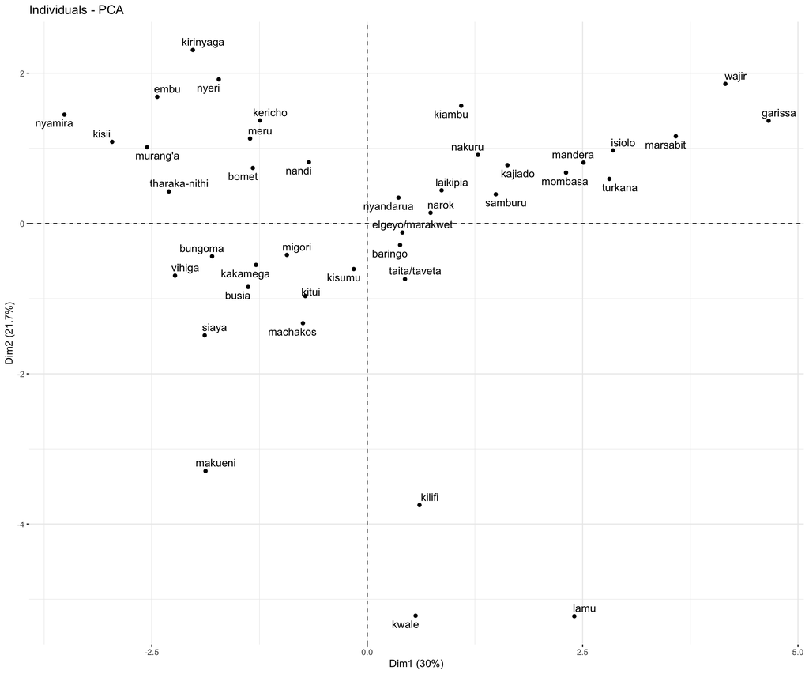

```r
# Score plot
pca_kenya %>%
  fviz_pca_ind(repel = TRUE)
```

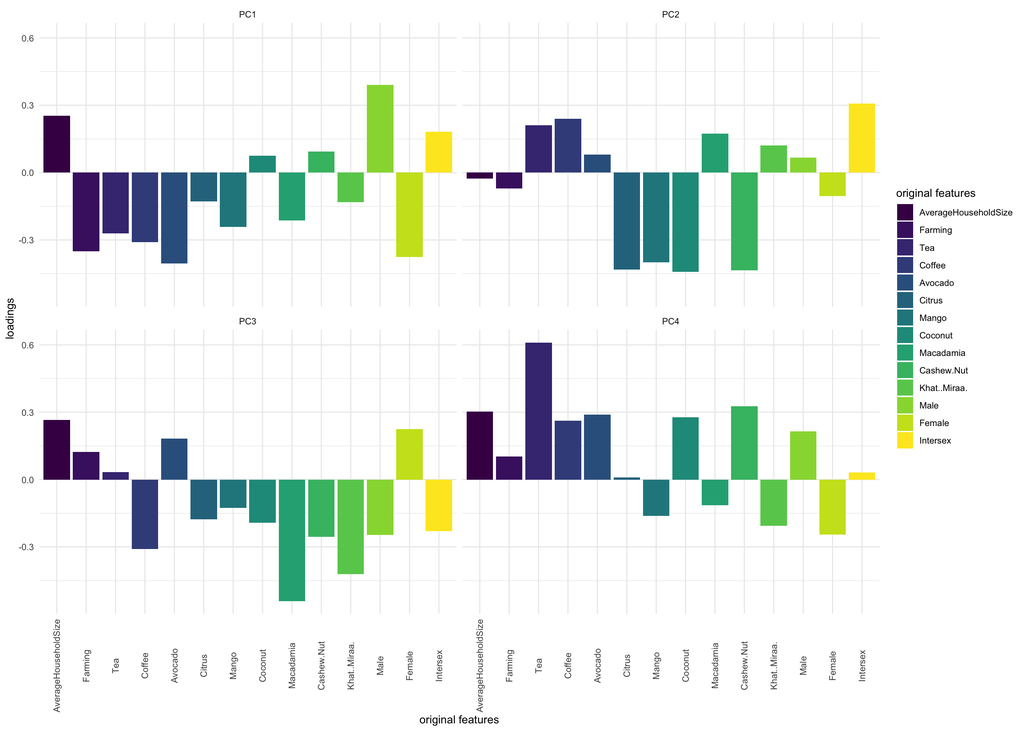

```r
# Bar plot

melt(pca_kenya$rotation[, 1:4]) %>%
  ggplot(aes(x = Var1, y = value, fill = Var1)) +
    geom_bar(stat = "identity") +
    facet_wrap(~ Var2) +
    labs(y = "loadings", x = "original features", fill = "original features") +
  scale_fill_viridis_d() +
  theme_minimal() +
 theme(axis.text.x = element_text(angle = 90, vjust = 0.5))
```

# Contributions

- Giovanny and Rishika: collaborated in the planning, implementation and analysis of the clustering models of the assignment. Giovanny worked on the K-means algorithm while Rishika worked on Hierarchical clustering. Rishika also conducted extra research to give further details of our data that is not included given our data context.
- Na: responsible for data cleaning, wrangling, EDA & import, PCA analysis, sf map graph to compare 2 clustering models, compile all research together.

We worked together to bring all our findings together.